# Fin Tech Project Group 8 _ 4th Dec

**Block 1: Data Ingestion & Initial Setup**

```python
# =============================================================================
# BLOCK 1: DATA INGESTION & INITIAL SETUP (CORRECTED)
# =============================================================================
# Purpose: Import libraries, load all CSV files, and examine basic structure
# =============================================================================

import pandas as pd
import numpy as np
import warnings
warnings.filterwarnings('ignore')

# Define file paths
data_path = r"C:\Users\Lenovo\OneDrive - Higher Education Commission\Desktop\MSBA\Module 6\FIN 591\Project"

# Dictionary mapping asset names to filenames (corrected with spaces)
files = {
    'BTC': 'Bitcoin Historical Data 2017-2025.csv',
    'ETH': 'Ethereum Historical Data 2017-2025.csv',
    'SP500': 'S&P 500 Historical Data 2017 -2025.csv',
    'NASDAQ': 'NASDAQ Composite Historical Data 2017-2025.csv',
    'Gold': 'Gold Historical Data 2017-2025.csv',
    'Oil': 'Crude Oil WTI Futures Historical Data 2017-2025.csv',
    'VIX': 'CBOE Volatility Index Historical Data 2017-2025.csv',
    'Treasury10Y': 'United States 10-Year Bond Yield Historical Data 2017-2025.csv'
}

# Load all datasets into a dictionary
raw_data = {}
for name, filename in files.items():
    filepath = f"{data_path}\\{filename}"
    raw_data[name] = pd.read_csv(filepath)
    print(f"{name}: {raw_data[name].shape[0]} rows, {raw_data[name].shape[1]} columns")

# Display sample of one dataset to verify structure
print("\n" + "="*50)
print("Sample: Bitcoin data (first 5 rows)")
print("="*50)
print(raw_data['BTC'].head())

print("\n" + "="*50)
print("Column names across all datasets:")
print("="*50)
for name, df in raw_data.items():
    print(f"{name}: {list(df.columns)}")
```

```
BTC: 3239 rows, 7 columns
ETH: 3239 rows, 7 columns
SP500: 2230 rows, 7 columns
NASDAQ: 2230 rows, 7 columns
Gold: 2306 rows, 7 columns
Oil: 2332 rows, 7 columns
VIX: 2268 rows, 7 columns
Treasury10Y: 2308 rows, 6 columns

==================================================
Sample: Bitcoin data (first 5 rows)
==================================================
         Date       Price        Open        High         Low     Vol.  \
0  11/13/2025   99,728.70  101,652.80  104,008.70   98,027.40  100.44K
1  11/12/2025  101,658.30  103,046.70  105,309.10  100,858.00   63.52K
2  11/11/2025  103,046.70  106,003.20  107,461.30  102,484.30   73.04K
3  11/10/2025  106,006.90  104,720.80  106,629.50  104,285.00   70.75K
4  11/09/2025  104,722.40  102,311.30  105,409.10  101,469.10   51.64K

  Change %
0   -1.90%
1   -1.35%
2   -2.79%
3    1.23%
4    2.36%

==================================================
Column names across all datasets:
==================================================
BTC: ['Date', 'Price', 'Open', 'High', 'Low', 'Vol.', 'Change %']
ETH: ['Date', 'Price', 'Open', 'High', 'Low', 'Vol.', 'Change %']
SP500: ['Date', 'Price', 'Open', 'High', 'Low', 'Vol.', 'Change %']
NASDAQ: ['Date', 'Price', 'Open', 'High', 'Low', 'Vol.', 'Change %']
Gold: ['Date', 'Price', 'Open', 'High', 'Low', 'Vol.', 'Change %']
Oil: ['Date', 'Price', 'Open', 'High', 'Low', 'Vol.', 'Change %']
VIX: ['Date', 'Price', 'Open', 'High', 'Low', 'Vol.', 'Change %']
Treasury10Y: ['Date', 'Price', 'Open', 'High', 'Low', 'Change %']
```

**Block 2: Data Cleaning & Formatting**

```python
# =============================================================================
# BLOCK 2: DATA CLEANING & FORMATTING
# =============================================================================
# Purpose: Clean numeric values, convert dates, standardize format
# =============================================================================

def clean_numeric(value):
    """
    Convert string values with commas and suffixes to float.
    Handles: '99,728.70', '100.44K', '1.78B', '329.52K', '-1.90%'
    """
    if pd.isna(value) or value == '' or value == '-':
        return np.nan

    if isinstance(value, (int, float)):
        return float(value)

    # Convert to string and clean
    value = str(value).strip()

    # Remove percentage sign
    if '%' in value:
        value = value.replace('%', '')

    # Remove commas
    value = value.replace(',', '')

    # Handle K, M, B suffixes
    multiplier = 1
    if value.endswith('K'):
        multiplier = 1_000
        value = value[:-1]
    elif value.endswith('M'):
        multiplier = 1_000_000
        value = value[:-1]
    elif value.endswith('B'):
        multiplier = 1_000_000_000
        value = value[:-1]

    try:
        return float(value) * multiplier
    except ValueError:
        return np.nan

# Clean each dataset
cleaned_data = {}

for name, df in raw_data.items():
    # Create a copy
    df_clean = df.copy()

    # Convert Date to datetime
    df_clean['Date'] = pd.to_datetime(df_clean['Date'], format='%m/%d/%Y')

    # Clean Price column (this is what we need for returns)
    df_clean['Price'] = df_clean['Price'].apply(clean_numeric)

    # Clean Change % column
    df_clean['Change %'] = df_clean['Change %'].apply(clean_numeric)

    # Sort by date (oldest first) and reset index
    df_clean = df_clean.sort_values('Date').reset_index(drop=True)

    # Store cleaned data
    cleaned_data[name] = df_clean

    # Report cleaning results
    null_count = df_clean['Price'].isna().sum()
    print(f"{name}: Date range {df_clean['Date'].min().date()} to {df_clean['Date'].max().date()}, "
          f"Null prices: {null_count}")

# Verify cleaning worked
print("\n" + "="*50)
print("Sample: Cleaned Bitcoin data (first 5 rows)")
print("="*50)
print(cleaned_data['BTC'][['Date', 'Price', 'Change %']].head())
print(f"\nData types:\n{cleaned_data['BTC'][['Date', 'Price', 'Change %']].dtypes}")
```

```
BTC: Date range 2017-01-01 to 2025-11-13, Null prices: 0
ETH: Date range 2017-01-01 to 2025-11-13, Null prices: 0
SP500: Date range 2017-01-03 to 2025-11-13, Null prices: 0
NASDAQ: Date range 2017-01-03 to 2025-11-13, Null prices: 0
Gold: Date range 2017-01-02 to 2025-11-13, Null prices: 0
Oil: Date range 2017-01-02 to 2025-11-13, Null prices: 0
VIX: Date range 2017-01-03 to 2025-11-13, Null prices: 0
Treasury10Y: Date range 2017-01-02 to 2025-11-13, Null prices: 0

==================================================
Sample: Cleaned Bitcoin data (first 5 rows)
==================================================
        Date   Price  Change %
0 2017-01-01   995.4      3.33
1 2017-01-02  1017.0      2.17
2 2017-01-03  1033.3      1.60
3 2017-01-04  1135.4      9.88
4 2017-01-05   989.3    -12.86

Data types:
Date        datetime64[ns]
Price              float64
Change %           float64
dtype: object
```

**Block 3: Date Alignment & Unified DataFrame**

```python
# =============================================================================
# BLOCK 3: DATE ALIGNMENT & UNIFIED DATAFRAME
# =============================================================================
# Purpose: Create a single DataFrame with all assets aligned on common dates
# =============================================================================

# Extract just Date and Price from each dataset, rename Price to asset name
price_dfs = []

for name, df in cleaned_data.items():
    temp = df[['Date', 'Price']].copy()
    temp = temp.rename(columns={'Price': name})
    temp = temp.set_index('Date')
    price_dfs.append(temp)

# Merge all on Date using inner join (only dates where ALL assets have data)
prices_df = price_dfs[0]
for df in price_dfs[1:]:
    prices_df = prices_df.join(df, how='inner')

# Reset index to make Date a column again
prices_df = prices_df.reset_index()

# Report results
print("="*60)
print("UNIFIED PRICE DATAFRAME")
print("="*60)
print(f"Total rows (common trading days): {len(prices_df)}")
print(f"Date range: {prices_df['Date'].min().date()} to {prices_df['Date'].max().date()}")
print(f"Columns: {list(prices_df.columns)}")

print("\n" + "="*60)
print("First 5 rows:")
print("="*60)
print(prices_df.head())

print("\n" + "="*60)
print("Last 5 rows:")
print("="*60)
print(prices_df.tail())

print("\n" + "="*60)
print("Missing values per column:")
print("="*60)
print(prices_df.isna().sum())

print("\n" + "="*60)
print("Data types:")
print("="*60)
print(prices_df.dtypes)
```

```
============================================================
UNIFIED PRICE DATAFRAME
============================================================
Total rows (common trading days): 2227
Date range: 2017-01-03 to 2025-11-13
Columns: ['Date', 'BTC', 'ETH', 'SP500', 'NASDAQ', 'Gold', 'Oil', 'VIX', 'Treasury10Y']

============================================================
First 5 rows:
============================================================
        Date     BTC    ETH   SP500   NASDAQ     Gold    Oil    VIX  \
0 2017-01-03  1033.3   9.74  2257.8  5429.08  1158.91  52.33  12.85
1 2017-01-04  1135.4  11.00  2270.8  5477.01  1163.80  53.26  11.85
2 2017-01-05   989.3  10.15  2269.0  5487.94  1180.48  53.76  11.67
3 2017-01-06   886.2  10.08  2277.0  5521.06  1172.81  53.99  11.32
4 2017-01-09   899.8  10.26  2268.9  5531.82  1181.27  51.96  11.56

   Treasury10Y
0        2.448
1        2.441
2        2.348
3        2.421
4        2.368

============================================================
Last 5 rows:
============================================================
           Date       BTC      ETH    SP500    NASDAQ     Gold    Oil    VIX  \
2222 2025-11-07  103325.4  3435.78  6728.80  23004.54  3999.72  59.75  19.08
2223 2025-11-10  106006.9  3567.87  6832.43  23527.17  4115.90  60.13  17.60
2224 2025-11-11  103046.7  3417.56  6846.61  23468.30  4126.68  61.04  17.28
2225 2025-11-12  101658.3  3413.60  6850.92  23406.46  4198.73  58.49  17.51
2226 2025-11-13   99728.7  3232.94  6737.54  22870.36  4186.04  58.69  20.00

      Treasury10Y
2222        4.093
2223        4.110
2224        4.069
2225        4.067
2226        4.111
```

[output cut: 13 more lines]

```
dtype: int64

============================================================
Data types:
============================================================
Date           datetime64[ns]
BTC                   float64
ETH                   float64
SP500                 float64
NASDAQ                float64
Gold                  float64
Oil                   float64
VIX                   float64
Treasury10Y           float64
dtype: object
```

**Block 4: Feature Engineering (Returns & Volatility**

```python
# =============================================================================
# BLOCK 4: FEATURE ENGINEERING - RETURNS & VOLATILITY
# =============================================================================
# Purpose: Compute daily log returns and rolling volatility for all assets
# =============================================================================

# List of price columns (excluding VIX and Treasury which are already rates/indices)
price_assets = ['BTC', 'ETH', 'SP500', 'NASDAQ', 'Gold', 'Oil']
macro_vars = ['VIX', 'Treasury10Y']

# Create a copy for returns
returns_df = prices_df[['Date']].copy()

# -----------------------------------------------------------------------------
# 4.1 Compute Daily Log Returns for price assets
# -----------------------------------------------------------------------------
for asset in price_assets:
    returns_df[f'{asset}_ret'] = np.log(prices_df[asset] / prices_df[asset].shift(1))

# For VIX and Treasury, compute simple changes (they're already rates/indices)
# VIX: compute log returns (it's an index)
returns_df['VIX_ret'] = np.log(prices_df['VIX'] / prices_df['VIX'].shift(1))

# Treasury: compute simple difference in yield (basis points perspective)
returns_df['Treasury10Y_chg'] = prices_df['Treasury10Y'] - prices_df['Treasury10Y'].shift(1)

# -----------------------------------------------------------------------------
# 4.2 Compute 20-day Rolling Volatility (annualized)
# -----------------------------------------------------------------------------
for asset in price_assets:
    # Rolling std of returns * sqrt(252) for annualization
    returns_df[f'{asset}_vol20'] = returns_df[f'{asset}_ret'].rolling(window=20).std() * np.sqrt(252)

# VIX volatility (rolling std of VIX changes)
returns_df['VIX_vol20'] = returns_df['VIX_ret'].rolling(window=20).std() * np.sqrt(252)

# -----------------------------------------------------------------------------
# 4.3 Add price levels for reference
# -----------------------------------------------------------------------------
for col in price_assets + macro_vars:
    returns_df[col] = prices_df[col]

# Drop rows with NaN (first ~20 rows due to rolling window)
returns_df = returns_df.dropna().reset_index(drop=True)

# Report results
print("="*60)
print("RETURNS & VOLATILITY DATAFRAME")
print("="*60)
print(f"Total rows: {len(returns_df)}")
print(f"Total columns: {len(returns_df.columns)}")
print(f"Date range: {returns_df['Date'].min().date()} to {returns_df['Date'].max().date()}")

print("\n" + "="*60)
print("Column names:")
print("="*60)
for i, col in enumerate(returns_df.columns):
    print(f"{i+1}. {col}")

print("\n" + "="*60)
print("Summary Statistics - Daily Returns:")
print("="*60)
return_cols = [col for col in returns_df.columns if '_ret' in col]
print(returns_df[return_cols].describe().round(4))

print("\n" + "="*60)
print("Summary Statistics - 20-day Rolling Volatility (Annualized):")
print("="*60)
vol_cols = [col for col in returns_df.columns if '_vol20' in col]
print(returns_df[vol_cols].describe().round(4))
```

```
============================================================
RETURNS & VOLATILITY DATAFRAME
============================================================
Total rows: 2207
Total columns: 24
Date range: 2017-02-01 to 2025-11-13

============================================================
Column names:
============================================================
1. Date
2. BTC_ret
3. ETH_ret
4. SP500_ret
5. NASDAQ_ret
6. Gold_ret
7. Oil_ret
8. VIX_ret
9. Treasury10Y_chg
10. BTC_vol20
11. ETH_vol20
12. SP500_vol20
13. NASDAQ_vol20
14. Gold_vol20
15. Oil_vol20
16. VIX_vol20
17. BTC
18. ETH
19. SP500
20. NASDAQ
21. Gold
22. Oil
23. VIX
24. Treasury10Y

============================================================
Summary Statistics - Daily Returns:
============================================================
         BTC_ret    ETH_ret  SP500_ret  NASDAQ_ret   Gold_ret    Oil_ret  \
count  2207.0000  2207.0000  2207.0000   2207.0000  2207.0000  2207.0000
```

[output cut: 25 more lines]

```
min       0.1488     0.1378       0.0329        0.0543      0.0441     0.1253
25%       0.4347     0.5876       0.0890        0.1211      0.1009     0.2361
50%       0.5707     0.7575       0.1270        0.1695      0.1245     0.2894
75%       0.7518     1.0075       0.1909        0.2496      0.1553     0.3880
max       2.0819     2.5699       0.9790        0.9551      0.3651     3.2717

       VIX_vol20
count  2207.0000
mean      1.1837
std       0.5307
min       0.3835
25%       0.8232
50%       1.0667
75%       1.3763
max       3.5141
```

**Commentary**

Daily Returns Summary Mean (average daily return):

- BTC: 0.21% per day, ETH: 0.26% per day → Crypto has the highest average returns
- SP500: 0.05%, NASDAQ: 0.06% → Equities much lower but positive
- Gold: 0.06%, Oil: ~0% → Commodities roughly flat on average

Std (daily volatility):

- BTC: 4.4%, ETH: 6.0% → Crypto is extremely volatile
- SP500: 1.2%, NASDAQ: 1.4% → Equities much calmer
- Oil: 3.1% → Surprisingly volatile (commodity price swings)
- VIX: 8.1% → VIX itself is very jumpy (fear spikes quickly)

Min/Max (extreme days):

- BTC dropped 50% in one day, ETH dropped 59% → massive crash days
- Oil had -57% and +58% → likely includes the 2020 COVID crash when oil went negative
- SP500 max drop was -12.8% → likely March 2020 COVID crash

20-Day Rolling Volatility (Annualized) This tells you "what was the typical annualized volatility over rolling 20-day windows":

- BTC: 63% average, ranging from 15% to 208%
- ETH: 85% average, ranging from 14% to 257%
- SP500: 15% average, ranging from 3% to 98%
- Gold: 14% average, very stable range

Key insight: Crypto volatility is 4-5x higher than equities on average, but the ranges overlap during crisis periods (SP500 hit 98% annualized vol during COVID crash).

**Block 5: Exploratory Data Analysis (EDA)**

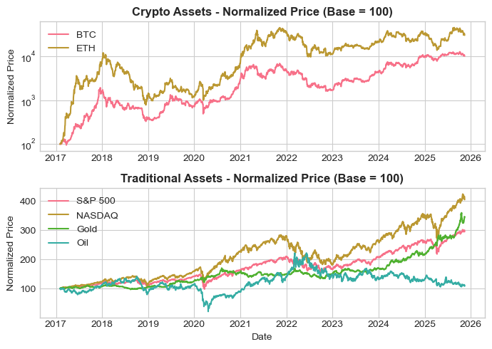

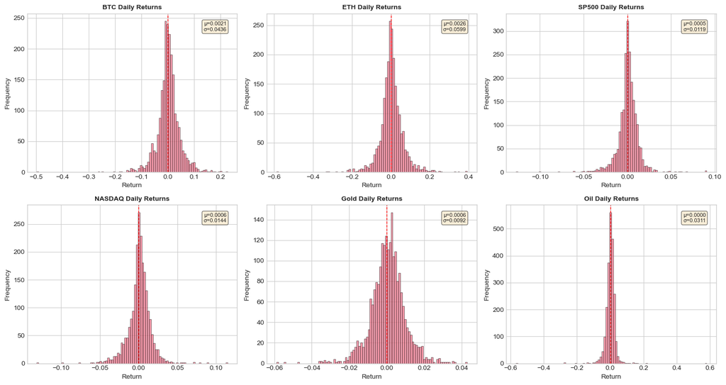

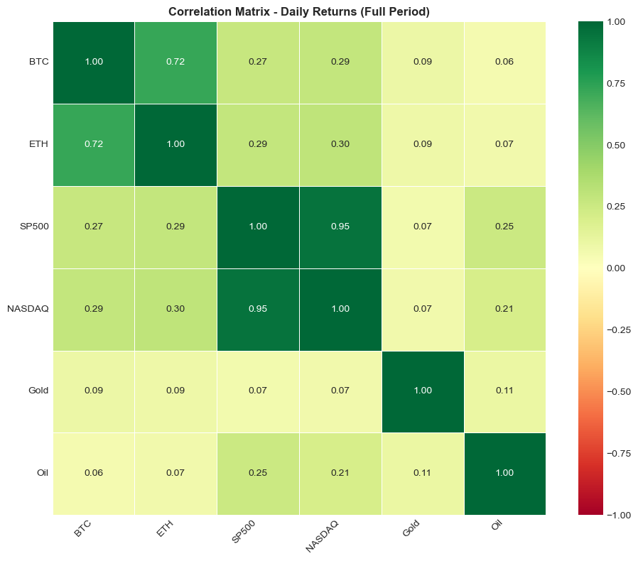

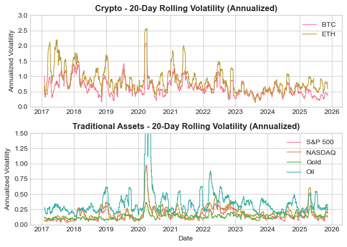

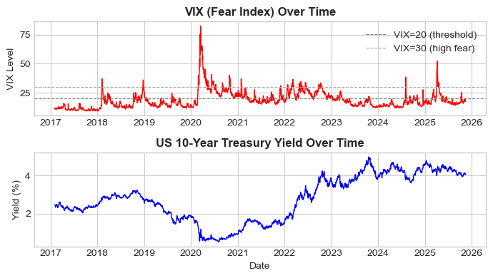

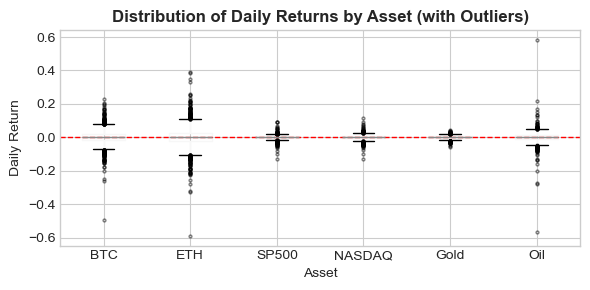

```
======================================================================
BLOCK 5: EDA SUMMARY OUTPUT
======================================================================

----------------------------------------------------------------------
1. TOTAL RETURNS (Start to End)
----------------------------------------------------------------------
BTC     :       982.40 →    99,728.70 | Total Return:  10051.5%
ETH     :        10.71 →     3,232.94 | Total Return:  30086.2%
SP500   :     2,279.60 →     6,737.54 | Total Return:    195.6%
NASDAQ  :     5,642.65 →    22,870.36 | Total Return:    305.3%
Gold    :     1,209.49 →     4,186.04 | Total Return:    246.1%
Oil     :        53.88 →        58.69 | Total Return:      8.9%

----------------------------------------------------------------------
2. FULL CORRELATION MATRIX
----------------------------------------------------------------------
          BTC    ETH  SP500  NASDAQ   Gold    Oil
BTC     1.000  0.720  0.272   0.287  0.094  0.061
ETH     0.720  1.000  0.286   0.298  0.092  0.074
SP500   0.272  0.286  1.000   0.950  0.068  0.253
NASDAQ  0.287  0.298  0.950   1.000  0.075  0.209
Gold    0.094  0.092  0.068   0.075  1.000  0.105
Oil     0.061  0.074  0.253   0.209  0.105  1.000

----------------------------------------------------------------------
3. KEY CORRELATION PAIRS
----------------------------------------------------------------------
BTC - ETH:      0.720
BTC - SP500:    0.272
BTC - NASDAQ:   0.287
BTC - Gold:     0.094
BTC - Oil:      0.061
ETH - SP500:    0.286
ETH - NASDAQ:   0.298
ETH - Gold:     0.092
ETH - Oil:      0.074
SP500 - NASDAQ: 0.950
SP500 - Gold:   0.068
SP500 - Oil:    0.253
```

[output cut: 19 more lines]

```
Days above 30 (high fear): 152
Days above 20 (elevated):  733

----------------------------------------------------------------------
6. 10-YEAR TREASURY YIELD SUMMARY
----------------------------------------------------------------------
Mean:   2.77%
Min:    0.51%
Max:    4.99%
Start:  2.48%
End:    4.11%

======================================================================
END OF EDA SUMMARY
======================================================================
```

```python
# =============================================================================
# BLOCK 5: EXPLORATORY DATA ANALYSIS (EDA)
# =============================================================================
# Purpose: Visualize prices, returns, correlations, and volatility patterns
# =============================================================================

import matplotlib.pyplot as plt
import seaborn as sns

# Set style
plt.style.use('seaborn-v0_8-whitegrid')
sns.set_palette("husl")

# -----------------------------------------------------------------------------
# 5.1 Price Time Series (Normalized to 100 at start for comparison)
# -----------------------------------------------------------------------------
fig, axes = plt.subplots(2, 1, figsize=(7, 5))

# Normalize prices to 100 at start date for comparison
price_cols = ['BTC', 'ETH', 'SP500', 'NASDAQ', 'Gold', 'Oil']
normalized_prices = returns_df[['Date'] + price_cols].copy()

for col in price_cols:
    normalized_prices[col] = (returns_df[col] / returns_df[col].iloc[0]) * 100

# Plot crypto vs traditional
ax1 = axes[0]
ax1.plot(normalized_prices['Date'], normalized_prices['BTC'], label='BTC', linewidth=1.5)
ax1.plot(normalized_prices['Date'], normalized_prices['ETH'], label='ETH', linewidth=1.5)
ax1.set_title('Crypto Assets - Normalized Price (Base = 100)', fontsize=12, fontweight='bold')
ax1.set_ylabel('Normalized Price')
ax1.legend(loc='upper left')
ax1.set_yscale('log')

ax2 = axes[1]
ax2.plot(normalized_prices['Date'], normalized_prices['SP500'], label='S&P 500', linewidth=1.5)
ax2.plot(normalized_prices['Date'], normalized_prices['NASDAQ'], label='NASDAQ', linewidth=1.5)
ax2.plot(normalized_prices['Date'], normalized_prices['Gold'], label='Gold', linewidth=1.5)
ax2.plot(normalized_prices['Date'], normalized_prices['Oil'], label='Oil', linewidth=1.5)
ax2.set_title('Traditional Assets - Normalized Price (Base = 100)', fontsize=12, fontweight='bold')
ax2.set_ylabel('Normalized Price')
ax2.set_xlabel('Date')
ax2.legend(loc='upper left')

plt.tight_layout()
plt.show()

# -----------------------------------------------------------------------------
# 5.2 Return Distributions (Histograms)
# -----------------------------------------------------------------------------
return_cols = ['BTC_ret', 'ETH_ret', 'SP500_ret', 'NASDAQ_ret', 'Gold_ret', 'Oil_ret']

fig, axes = plt.subplots(2, 3, figsize=(15, 8))
axes = axes.flatten()

for i, col in enumerate(return_cols):
    ax = axes[i]
    returns_df[col].hist(bins=100, ax=ax, alpha=0.7, edgecolor='black', linewidth=0.5)
    ax.axvline(x=0, color='red', linestyle='--', linewidth=1)
    ax.set_title(f'{col.replace("_ret", "")} Daily Returns', fontsize=10, fontweight='bold')
    ax.set_xlabel('Return')
    ax.set_ylabel('Frequency')

    mean_val = returns_df[col].mean()
    std_val = returns_df[col].std()
    ax.annotate(f'μ={mean_val:.4f}\nσ={std_val:.4f}',
                xy=(0.95, 0.95), xycoords='axes fraction',
                ha='right', va='top', fontsize=8,
                bbox=dict(boxstyle='round', facecolor='wheat', alpha=0.5))

plt.tight_layout()
plt.show()

# -----------------------------------------------------------------------------
# 5.3 Correlation Matrix of Returns
# -----------------------------------------------------------------------------
corr_matrix = returns_df[return_cols].corr()

fig, ax = plt.subplots(figsize=(10, 8))
sns.heatmap(corr_matrix, annot=True, cmap='RdYlGn', center=0,
            fmt='.2f', square=True, linewidths=0.5, ax=ax,
            vmin=-1, vmax=1)
ax.set_title('Correlation Matrix - Daily Returns (Full Period)', fontsize=12, fontweight='bold')

labels = [col.replace('_ret', '') for col in return_cols]
ax.set_xticklabels(labels, rotation=45, ha='right')
ax.set_yticklabels(labels, rotation=0)

plt.tight_layout()
plt.show()

# -----------------------------------------------------------------------------
# 5.4 Rolling Volatility Over Time
# -----------------------------------------------------------------------------
vol_cols = ['BTC_vol20', 'ETH_vol20', 'SP500_vol20', 'NASDAQ_vol20', 'Gold_vol20', 'Oil_vol20']

fig, axes = plt.subplots(2, 1, figsize=(7, 5))

ax1 = axes[0]
ax1.plot(returns_df['Date'], returns_df['BTC_vol20'], label='BTC', linewidth=1)
ax1.plot(returns_df['Date'], returns_df['ETH_vol20'], label='ETH', linewidth=1)
ax1.set_title('Crypto - 20-Day Rolling Volatility (Annualized)', fontsize=12, fontweight='bold')
ax1.set_ylabel('Annualized Volatility')
ax1.legend(loc='upper right')
ax1.set_ylim(0, 3)

ax2 = axes[1]
ax2.plot(returns_df['Date'], returns_df['SP500_vol20'], label='S&P 500', linewidth=1)
ax2.plot(returns_df['Date'], returns_df['NASDAQ_vol20'], label='NASDAQ', linewidth=1)
ax2.plot(returns_df['Date'], returns_df['Gold_vol20'], label='Gold', linewidth=1)
ax2.plot(returns_df['Date'], returns_df['Oil_vol20'], label='Oil', linewidth=1)
ax2.set_title('Traditional Assets - 20-Day Rolling Volatility (Annualized)', fontsize=12, fontweight='bold')
ax2.set_ylabel('Annualized Volatility')
ax2.set_xlabel('Date')
ax2.legend(loc='upper right')
ax2.set_ylim(0, 1.5)

plt.tight_layout()
plt.show()

# -----------------------------------------------------------------------------
# 5.5 VIX and Treasury Yield Over Time
# -----------------------------------------------------------------------------
fig, axes = plt.subplots(2, 1, figsize=(7, 4))

ax1 = axes[0]
ax1.plot(returns_df['Date'], returns_df['VIX'], color='red', linewidth=1)
ax1.axhline(y=20, color='gray', linestyle='--', linewidth=0.8, label='VIX=20 (threshold)')
ax1.axhline(y=30, color='darkgray', linestyle='--', linewidth=0.8, label='VIX=30 (high fear)')
ax1.set_title('VIX (Fear Index) Over Time', fontsize=12, fontweight='bold')
ax1.set_ylabel('VIX Level')
ax1.legend(loc='upper right')

ax2 = axes[1]
ax2.plot(returns_df['Date'], returns_df['Treasury10Y'], color='blue', linewidth=1)
ax2.set_title('US 10-Year Treasury Yield Over Time', fontsize=12, fontweight='bold')
ax2.set_ylabel('Yield (%)')
ax2.set_xlabel('Date')

plt.tight_layout()
plt.show()

# -----------------------------------------------------------------------------
# 5.6 Boxplots of Returns by Asset
# -----------------------------------------------------------------------------
fig, ax = plt.subplots(figsize=(6, 3))

returns_for_box = returns_df[return_cols].copy()
returns_for_box.columns = [col.replace('_ret', '') for col in return_cols]

returns_for_box.boxplot(ax=ax, showfliers=True, flierprops=dict(marker='o', markersize=2, alpha=0.5))
ax.axhline(y=0, color='red', linestyle='--', linewidth=1)
ax.set_title('Distribution of Daily Returns by Asset (with Outliers)', fontsize=12, fontweight='bold')
ax.set_ylabel('Daily Return')
ax.set_xlabel('Asset')

plt.tight_layout()
plt.show()

# =============================================================================
# TEXTUAL SUMMARY OUTPUT
# =============================================================================

print("="*70)
print("BLOCK 5: EDA SUMMARY OUTPUT")
print("="*70)

# Price performance
print("\n" + "-"*70)
print("1. TOTAL RETURNS (Start to End)")
print("-"*70)
for col in price_cols:
    start_price = returns_df[col].iloc[0]
    end_price = returns_df[col].iloc[-1]
    total_return = ((end_price / start_price) - 1) * 100
    print(f"{col:8s}: {start_price:>12,.2f} → {end_price:>12,.2f} | Total Return: {total_return:>8.1f}%")

# Correlation matrix
print("\n" + "-"*70)
print("2. FULL CORRELATION MATRIX")
print("-"*70)
corr_display = corr_matrix.copy()
corr_display.index = [c.replace('_ret', '') for c in corr_display.index]
corr_display.columns = [c.replace('_ret', '') for c in corr_display.columns]
print(corr_display.round(3).to_string())

# Key correlations
print("\n" + "-"*70)
print("3. KEY CORRELATION PAIRS")
print("-"*70)
print(f"BTC - ETH:      {corr_matrix.loc['BTC_ret', 'ETH_ret']:.3f}")
print(f"BTC - SP500:    {corr_matrix.loc['BTC_ret', 'SP500_ret']:.3f}")
print(f"BTC - NASDAQ:   {corr_matrix.loc['BTC_ret', 'NASDAQ_ret']:.3f}")
print(f"BTC - Gold:     {corr_matrix.loc['BTC_ret', 'Gold_ret']:.3f}")
print(f"BTC - Oil:      {corr_matrix.loc['BTC_ret', 'Oil_ret']:.3f}")
print(f"ETH - SP500:    {corr_matrix.loc['ETH_ret', 'SP500_ret']:.3f}")
print(f"ETH - NASDAQ:   {corr_matrix.loc['ETH_ret', 'NASDAQ_ret']:.3f}")
print(f"ETH - Gold:     {corr_matrix.loc['ETH_ret', 'Gold_ret']:.3f}")
print(f"ETH - Oil:      {corr_matrix.loc['ETH_ret', 'Oil_ret']:.3f}")
print(f"SP500 - NASDAQ: {corr_matrix.loc['SP500_ret', 'NASDAQ_ret']:.3f}")
print(f"SP500 - Gold:   {corr_matrix.loc['SP500_ret', 'Gold_ret']:.3f}")
print(f"SP500 - Oil:    {corr_matrix.loc['SP500_ret', 'Oil_ret']:.3f}")
print(f"Gold - Oil:     {corr_matrix.loc['Gold_ret', 'Oil_ret']:.3f}")

# Volatility summary
print("\n" + "-"*70)
print("4. AVERAGE ANNUALIZED VOLATILITY (20-day rolling)")
print("-"*70)
for col in vol_cols:
    asset_name = col.replace('_vol20', '')
    avg_vol = returns_df[col].mean() * 100
    max_vol = returns_df[col].max() * 100
    print(f"{asset_name:8s}: Avg = {avg_vol:>6.1f}% | Max = {max_vol:>6.1f}%")

# VIX summary
print("\n" + "-"*70)
print("5. VIX SUMMARY")
print("-"*70)
print(f"Mean:   {returns_df['VIX'].mean():.2f}")
print(f"Median: {returns_df['VIX'].median():.2f}")
print(f"Min:    {returns_df['VIX'].min():.2f}")
print(f"Max:    {returns_df['VIX'].max():.2f}")
print(f"Days above 30 (high fear): {(returns_df['VIX'] > 30).sum()}")
print(f"Days above 20 (elevated):  {(returns_df['VIX'] > 20).sum()}")

# Treasury summary
print("\n" + "-"*70)
print("6. 10-YEAR TREASURY YIELD SUMMARY")
print("-"*70)
print(f"Mean:   {returns_df['Treasury10Y'].mean():.2f}%")
print(f"Min:    {returns_df['Treasury10Y'].min():.2f}%")
print(f"Max:    {returns_df['Treasury10Y'].max():.2f}%")
print(f"Start:  {returns_df['Treasury10Y'].iloc[0]:.2f}%")
print(f"End:    {returns_df['Treasury10Y'].iloc[-1]:.2f}%")

print("\n" + "="*70)
print("END OF EDA SUMMARY")
print("="*70)
```

**Block 6: Feature Standardization + HMM setup**

```python
# =============================================================================
# BLOCK 6: FEATURE STANDARDIZATION FOR ML MODELS
# =============================================================================
# Purpose: Select features and standardize them for HMM & K-Means
# =============================================================================
from sklearn.preprocessing import StandardScaler

# -----------------------------------------------------------------------------
# 6.1 Select Features for Regime Detection
# -----------------------------------------------------------------------------
# Feature set for regime detection
# Returns: capture direction of markets
# Volatility: capture turbulence
# VIX: capture fear/risk sentiment

feature_cols = [
    # Returns (6 assets)
    'BTC_ret', 'ETH_ret', 'SP500_ret', 'NASDAQ_ret', 'Gold_ret', 'Oil_ret',
    # Volatility (crypto and equity)
    'BTC_vol20', 'ETH_vol20', 'SP500_vol20',
    # Macro indicator
    'VIX'
]

# Extract features
features_raw = returns_df[feature_cols].copy()

# -----------------------------------------------------------------------------
# 6.2 Apply StandardScaler (Z-score normalization)
# -----------------------------------------------------------------------------
scaler = StandardScaler()
features_scaled = scaler.fit_transform(features_raw)

# Convert back to DataFrame for readability
features_df = pd.DataFrame(
    features_scaled,
    columns=feature_cols,
    index=returns_df.index
)

# Add Date for reference
features_df.insert(0, 'Date', returns_df['Date'].values)

# -----------------------------------------------------------------------------
# 6.3 Verify Standardization
# -----------------------------------------------------------------------------
print("="*70)
print("BLOCK 6: FEATURE STANDARDIZATION OUTPUT")
print("="*70)

print("\n" + "-"*70)
print("1. SELECTED FEATURES FOR REGIME DETECTION")
print("-"*70)
for i, col in enumerate(feature_cols, 1):
    print(f"{i}. {col}")

print("\n" + "-"*70)
print("2. RAW FEATURES - BEFORE STANDARDIZATION")
print("-"*70)
print(features_raw.describe().round(4).to_string())

print("\n" + "-"*70)
print("3. STANDARDIZED FEATURES - AFTER SCALING")
print("-"*70)
print(features_df[feature_cols].describe().round(4).to_string())

print("\n" + "-"*70)
print("4. VERIFICATION: Mean ≈ 0, Std ≈ 1")
print("-"*70)
print(f"{'Feature':<15} {'Mean':>10} {'Std':>10}")
print("-"*35)
for col in feature_cols:
    mean_val = features_df[col].mean()
    std_val = features_df[col].std()
    print(f"{col:<15} {mean_val:>10.6f} {std_val:>10.6f}")

print("\n" + "-"*70)
print("5. SAMPLE DATA (First 5 rows)")
print("-"*70)
print(features_df.head().to_string())

print("\n" + "-"*70)
print("6. DATA SHAPE")
print("-"*70)
print(f"Rows: {len(features_df)}")
print(f"Feature columns: {len(feature_cols)}")

print("\n" + "="*70)
print("END OF BLOCK 6")
print("="*70)
```

```
======================================================================
BLOCK 6: FEATURE STANDARDIZATION OUTPUT
======================================================================

----------------------------------------------------------------------
1. SELECTED FEATURES FOR REGIME DETECTION
----------------------------------------------------------------------
1. BTC_ret
2. ETH_ret
3. SP500_ret
4. NASDAQ_ret
5. Gold_ret
6. Oil_ret
7. BTC_vol20
8. ETH_vol20
9. SP500_vol20
10. VIX

----------------------------------------------------------------------
2. RAW FEATURES - BEFORE STANDARDIZATION
----------------------------------------------------------------------
         BTC_ret    ETH_ret  SP500_ret  NASDAQ_ret   Gold_ret    Oil_ret  BTC_vol20  ETH_vol20  SP500_vol20        VIX
count  2207.0000  2207.0000  2207.0000   2207.0000  2207.0000  2207.0000  2207.0000  2207.0000    2207.0000  2207.0000
mean      0.0021     0.0026     0.0005      0.0006     0.0006     0.0000     0.6287     0.8540       0.1541    18.8808
std       0.0436     0.0599     0.0119      0.0144     0.0092     0.0311     0.2812     0.3962       0.1096     7.6053
min      -0.4973    -0.5896    -0.1277     -0.1315    -0.0590    -0.5686     0.1488     0.1378       0.0329     9.1400
25%      -0.0167    -0.0245    -0.0038     -0.0052    -0.0043    -0.0117     0.4347     0.5876       0.0890    13.7400
50%       0.0016     0.0009     0.0008      0.0012     0.0008     0.0017     0.5707     0.7575       0.1270    17.1300
75%       0.0216     0.0287     0.0060      0.0079     0.0056     0.0130     0.7518     1.0075       0.1909    21.9050
max       0.2276     0.3925     0.0909      0.1148     0.0430     0.5812     2.0819     2.5699       0.9790    82.6900

----------------------------------------------------------------------
3. STANDARDIZED FEATURES - AFTER SCALING
----------------------------------------------------------------------
         BTC_ret    ETH_ret  SP500_ret  NASDAQ_ret   Gold_ret    Oil_ret  BTC_vol20  ETH_vol20  SP500_vol20        VIX
count  2207.0000  2207.0000  2207.0000   2207.0000  2207.0000  2207.0000  2207.0000  2207.0000    2207.0000  2207.0000
mean      0.0000     0.0000     0.0000      0.0000     0.0000     0.0000     0.0000    -0.0000      -0.0000     0.0000
std       1.0002     1.0002     1.0002      1.0002     1.0002     1.0002     1.0002     1.0002       1.0002     1.0002
min     -11.4679    -9.8916   -10.8067     -9.1809    -6.4881   -18.2991    -1.7073    -1.8079      -1.1059    -1.2811
25%      -0.4312    -0.4528    -0.3611     -0.4034    -0.5315    -0.3793    -0.6902    -0.6725      -0.5934    -0.6761
```

[output cut: 24 more lines]

```
0 2017-02-01  0.350233 -0.043212  -0.015521    0.299706 -0.163925  0.643966   1.324701  -0.472311    -0.871034 -0.929938
1 2017-02-02  0.451191  0.096557   0.002960   -0.123689  0.517451 -0.205253   1.105009  -0.880720    -0.901909 -0.914156
2 2017-02-03  0.156684  0.156634   0.570121    0.331640  0.292181  0.172297   0.612476  -1.121613    -0.854604 -1.040413
3 2017-02-06  0.215460  0.542368  -0.217796   -0.083711  1.333207 -0.495524   0.199381  -1.090123    -0.857223 -0.987806
4 2017-02-07  0.503102  0.089055  -0.023030    0.086567 -0.226312 -0.515560   0.206713  -1.095764    -0.873521 -0.998328

----------------------------------------------------------------------
6. DATA SHAPE
----------------------------------------------------------------------
Rows: 2207
Feature columns: 10

======================================================================
END OF BLOCK 6
======================================================================
```

**Block 7: Hidden Markov Model (Regime Detection)**

```python
pip install hmmlearn
```